# Part I - Prosper Loan Data Exploration

## by Blessed Utomi Job-Aigbovbioise

## Introduction

> This document explores a dataset containing about 114,000 rows of data on loans and includes details such as borrower rates(interest rate), borrower income and many others.

## Preliminary Wrangling

```python
# import all packages and set plots to be embedded inline
import numpy as np
import pandas as pd
import matplotlib.pyplot as plt
import seaborn as sb

%matplotlib inline
```

```python
loan = pd.read_csv('prosperLoanData.csv')
```

```python
# Overview of the shape and composition of the dataset
print(loan.shape)
print(loan.dtypes)
print(loan.head(10))
```

```
(113937, 81)
ListingKey                              object
ListingNumber                            int64
ListingCreationDate                     object
CreditGrade                             object
Term                                     int64
LoanStatus                              object
ClosedDate                              object
BorrowerAPR                            float64
BorrowerRate                           float64
LenderYield                            float64
EstimatedEffectiveYield                float64
EstimatedLoss                          float64
EstimatedReturn                        float64
ProsperRating (numeric)                float64
ProsperRating (Alpha)                   object
ProsperScore                           float64
ListingCategory (numeric)                int64
BorrowerState                           object
Occupation                              object
EmploymentStatus                        object
EmploymentStatusDuration               float64
IsBorrowerHomeowner                       bool
CurrentlyInGroup                          bool
GroupKey                                object
DateCreditPulled                        object
CreditScoreRangeLower                  float64
CreditScoreRangeUpper                  float64
FirstRecordedCreditLine                 object
CurrentCreditLines                     float64
OpenCreditLines                        float64
                                        ...
TotalProsperLoans                      float64
TotalProsperPaymentsBilled             float64
OnTimeProsperPayments                  float64
ProsperPaymentsLessThanOneMonthLate    float64
ProsperPaymentsOneMonthPlusLate        float64
ProsperPrincipalBorrowed               float64
ProsperPrincipalOutstanding            float64
ScorexChangeAtTimeOfListing            float64
```

[output cut: 81 more lines]

```
9            1.0                0                          0

  InvestmentFromFriendsAmount Investors
0                         0.0       258
1                         0.0         1
2                         0.0        41
3                         0.0       158
4                         0.0        20
5                         0.0         1
6                         0.0         1
7                         0.0         1
8                         0.0         1
9                         0.0         1

[10 rows x 81 columns]
```

```python
# Overview of columns
loan.columns
```

```
Index(['ListingKey', 'ListingNumber', 'ListingCreationDate', 'CreditGrade',
       'Term', 'LoanStatus', 'ClosedDate', 'BorrowerAPR', 'BorrowerRate',
       'LenderYield', 'EstimatedEffectiveYield', 'EstimatedLoss',
       'EstimatedReturn', 'ProsperRating (numeric)', 'ProsperRating (Alpha)',
       'ProsperScore', 'ListingCategory (numeric)', 'BorrowerState',
       'Occupation', 'EmploymentStatus', 'EmploymentStatusDuration',
       'IsBorrowerHomeowner', 'CurrentlyInGroup', 'GroupKey',
       'DateCreditPulled', 'CreditScoreRangeLower', 'CreditScoreRangeUpper',
       'FirstRecordedCreditLine', 'CurrentCreditLines', 'OpenCreditLines',
       'TotalCreditLinespast7years', 'OpenRevolvingAccounts',
       'OpenRevolvingMonthlyPayment', 'InquiriesLast6Months', 'TotalInquiries',
       'CurrentDelinquencies', 'AmountDelinquent', 'DelinquenciesLast7Years',
       'PublicRecordsLast10Years', 'PublicRecordsLast12Months',
       'RevolvingCreditBalance', 'BankcardUtilization',
       'AvailableBankcardCredit', 'TotalTrades',
       'TradesNeverDelinquent (percentage)', 'TradesOpenedLast6Months',
       'DebtToIncomeRatio', 'IncomeRange', 'IncomeVerifiable',
       'StatedMonthlyIncome', 'LoanKey', 'TotalProsperLoans',
       'TotalProsperPaymentsBilled', 'OnTimeProsperPayments',
       'ProsperPaymentsLessThanOneMonthLate',
       'ProsperPaymentsOneMonthPlusLate', 'ProsperPrincipalBorrowed',
       'ProsperPrincipalOutstanding', 'ScorexChangeAtTimeOfListing',
       'LoanCurrentDaysDelinquent', 'LoanFirstDefaultedCycleNumber',
       'LoanMonthsSinceOrigination', 'LoanNumber', 'LoanOriginalAmount',
       'LoanOriginationDate', 'LoanOriginationQuarter', 'MemberKey',
       'MonthlyLoanPayment', 'LP_CustomerPayments',
       'LP_CustomerPrincipalPayments', 'LP_InterestandFees', 'LP_ServiceFees',
       'LP_CollectionFees', 'LP_GrossPrincipalLoss', 'LP_NetPrincipalLoss',
       'LP_NonPrincipalRecoverypayments', 'PercentFunded', 'Recommendations',
       'InvestmentFromFriendsCount', 'InvestmentFromFriendsAmount',
       'Investors'],
      dtype='object')
```

Out of the 113937 rows and 81 columns, we'd only require the below 18 columns for our exploratory analysis.

```python
# Extracting the subset of columns (18) that'd be required for our analysis
df_loan_sub = loan_df.loc[:, ['ListingNumber','Term', 'LoanStatus', 'IncomeRange',
             'ProsperRating (Alpha)', 'ProsperScore', 'ListingCategory (numeric)', 'BorrowerState', 'Occupation',
             'EmploymentStatus', 'EmploymentStatusDuration', 'DebtToIncomeRatio', 'IsBorrowerHomeowner',
             'StatedMonthlyIncome', 'LoanOriginalAmount', 'LoanOriginationDate', 'LoanOriginationQuarter', 'MonthlyLoanPayment']]
```

### Assess

```python
# checking the first few rows
df_loan_sub.head()
```

|  | ListingNumber | Term | LoanStatus | IncomeRange | ProsperRating (Alpha) | ProsperScore | ListingCategory (numeric) | BorrowerState | Occupation | EmploymentStatus | EmploymentStatusDuration | DebtToIncomeRatio | IsBorrowerHomeowner | StatedMonthlyIncome | LoanOriginalAmount | LoanOriginationDate | LoanOriginationQuarter | MonthlyLoanPayment |
| --- | --- | --- | --- | --- | --- | --- | --- | --- | --- | --- | --- | --- | --- | --- | --- | --- | --- | --- |
| 0 | 193129 | 36 | Completed | $25,000-49,999 | NaN | NaN | 0 | CO | Other | Self-employed | 2.0 | 0.17 | True | 3083.333333 | 9425 | 2007-09-12 00:00:00 | Q3 2007 | 330.43 |
| 1 | 1209647 | 36 | Current | $50,000-74,999 | A | 7.0 | 2 | CO | Professional | Employed | 44.0 | 0.18 | False | 6125.000000 | 10000 | 2014-03-03 00:00:00 | Q1 2014 | 318.93 |
| 2 | 81716 | 36 | Completed | Not displayed | NaN | NaN | 0 | GA | Other | Not available | NaN | 0.06 | False | 2083.333333 | 3001 | 2007-01-17 00:00:00 | Q1 2007 | 123.32 |
| 3 | 658116 | 36 | Current | $25,000-49,999 | A | 9.0 | 16 | GA | Skilled Labor | Employed | 113.0 | 0.15 | True | 2875.000000 | 10000 | 2012-11-01 00:00:00 | Q4 2012 | 321.45 |
| 4 | 909464 | 36 | Current | $100,000+ | D | 4.0 | 2 | MN | Executive | Employed | 44.0 | 0.26 | True | 9583.333333 | 15000 | 2013-09-20 00:00:00 | Q3 2013 | 563.97 |

```python
df_loan_sub.info()
```

```
<class 'pandas.core.frame.DataFrame'>
RangeIndex: 113937 entries, 0 to 113936
Data columns (total 18 columns):
ListingNumber                113937 non-null int64
Term                         113937 non-null int64
LoanStatus                   113937 non-null object
IncomeRange                  113937 non-null object
ProsperRating (Alpha)        84853 non-null object
ProsperScore                 84853 non-null float64
ListingCategory (numeric)    113937 non-null int64
BorrowerState                108422 non-null object
Occupation                   110349 non-null object
EmploymentStatus             111682 non-null object
EmploymentStatusDuration     106312 non-null float64
DebtToIncomeRatio            105383 non-null float64
IsBorrowerHomeowner          113937 non-null bool
StatedMonthlyIncome          113937 non-null float64
LoanOriginalAmount           113937 non-null int64
LoanOriginationDate          113937 non-null object
LoanOriginationQuarter       113937 non-null object
MonthlyLoanPayment           113937 non-null float64
dtypes: bool(1), float64(5), int64(4), object(8)
memory usage: 14.9+ MB
```

```python
df_loan_sub.duplicated().sum()
```

[output not shown]

```python
df_loan_sub.LoanStatus.value_counts()
```

```
Current                   56576
Completed                 38074
Chargedoff                11992
Defaulted                  5018
Past Due (1-15 days)        806
Past Due (31-60 days)       363
Past Due (61-90 days)       313
Past Due (91-120 days)      304
Past Due (16-30 days)       265
FinalPaymentInProgress      205
Past Due (>120 days)         16
Cancelled                     5
Name: LoanStatus, dtype: int64
```

```python
df_loan_sub.IsBorrowerHomeowner.value_counts()
```

```
True     57478
False    56459
Name: IsBorrowerHomeowner, dtype: int64
```

```python
df_loan_sub['ListingCategory (numeric)'].value_counts()
```

```
1     58308
0     16965
7     10494
2      7433
3      7189
6      2572
4      2395
13     1996
15     1522
18      885
14      876
20      771
19      768
5       756
16      304
11      217
8       199
10       91
9        85
12       59
17       52
Name: ListingCategory (numeric), dtype: int64
```

### Observations

- Null values in ProsperRating (Alpha), ProsperScore, BorrowerState, Occupation, EmploymentStatus, EmploymentStatusDuration, DebtToIncomeRatio.
- Converting Occupation, BorrowerState, ListingCategory (numeric), EmploymentStatus, ProsperRating, ProsperScore, IncomeRange to Categorical variable, ListingNumber to string and LoanOriginationDate to datetime(Extract year, month, day and time)
- Round StatedMonthlyIncome to the nearest whole number(amount in dollars)

### Clean

```python
# We'd be working with a copy of the dataset.
df_loan_clean = df_loan_sub.copy()
```

```python
df_loan_clean
```

|  | ListingNumber | Term | LoanStatus | IncomeRange | ProsperRating (Alpha) | ProsperScore | ListingCategory (numeric) | BorrowerState | Occupation | EmploymentStatus | EmploymentStatusDuration | DebtToIncomeRatio | IsBorrowerHomeowner | StatedMonthlyIncome | LoanOriginalAmount | LoanOriginationDate | LoanOriginationQuarter | MonthlyLoanPayment |
| --- | --- | --- | --- | --- | --- | --- | --- | --- | --- | --- | --- | --- | --- | --- | --- | --- | --- | --- |
| 0 | 193129 | 36 | Completed | $25,000-49,999 | NaN | NaN | 0 | CO | Other | Self-employed | 2.0 | 0.17000 | True | 3083.333333 | 9425 | 2007-09-12 00:00:00 | Q3 2007 | 330.43 |
| 1 | 1209647 | 36 | Current | $50,000-74,999 | A | 7.0 | 2 | CO | Professional | Employed | 44.0 | 0.18000 | False | 6125.000000 | 10000 | 2014-03-03 00:00:00 | Q1 2014 | 318.93 |
| 2 | 81716 | 36 | Completed | Not displayed | NaN | NaN | 0 | GA | Other | Not available | NaN | 0.06000 | False | 2083.333333 | 3001 | 2007-01-17 00:00:00 | Q1 2007 | 123.32 |
| 3 | 658116 | 36 | Current | $25,000-49,999 | A | 9.0 | 16 | GA | Skilled Labor | Employed | 113.0 | 0.15000 | True | 2875.000000 | 10000 | 2012-11-01 00:00:00 | Q4 2012 | 321.45 |
| 4 | 909464 | 36 | Current | $100,000+ | D | 4.0 | 2 | MN | Executive | Employed | 44.0 | 0.26000 | True | 9583.333333 | 15000 | 2013-09-20 00:00:00 | Q3 2013 | 563.97 |
| 5 | 1074836 | 60 | Current | $100,000+ | B | 10.0 | 1 | NM | Professional | Employed | 82.0 | 0.36000 | True | 8333.333333 | 15000 | 2013-12-24 00:00:00 | Q4 2013 | 342.37 |
| 6 | 750899 | 36 | Current | $25,000-49,999 | E | 2.0 | 1 | KS | Sales - Retail | Employed | 172.0 | 0.27000 | False | 2083.333333 | 3000 | 2013-04-18 00:00:00 | Q2 2013 | 122.67 |
| 7 | 768193 | 36 | Current | $25,000-49,999 | C | 4.0 | 2 | CA | Laborer | Employed | 103.0 | 0.24000 | False | 3355.750000 | 10000 | 2013-05-13 00:00:00 | Q2 2013 | 372.60 |
| 8 | 1023355 | 36 | Current | $25,000-49,999 | AA | 9.0 | 7 | IL | Food Service | Employed | 269.0 | 0.25000 | True | 3333.333333 | 10000 | 2013-12-12 00:00:00 | Q4 2013 | 305.54 |
| 9 | 1023355 | 36 | Current | $25,000-49,999 | AA | 11.0 | 7 | IL | Food Service | Employed | 269.0 | 0.25000 | True | 3333.333333 | 10000 | 2013-12-12 00:00:00 | Q4 2013 | 305.54 |
| 10 | 587746 | 60 | Current | $75,000-99,999 | C | 7.0 | 1 | MD | Fireman | Employed | 300.0 | 0.12000 | False | 7500.000000 | 13500 | 2012-05-17 00:00:00 | Q2 2012 | 395.37 |
| 11 | 213551 | 36 | Completed | $1-24,999 | NaN | NaN | 0 | NaN | Waiter/Waitress | Full-time | 19.0 | 0.27000 | False | 1666.666667 | 1000 | 2007-10-18 00:00:00 | Q4 2007 | 33.81 |
| 12 | 1081604 | 36 | Past Due (1-15 days) | $25,000-49,999 | B | 4.0 | 1 | AL | Sales - Retail | Employed | 1.0 | 0.18000 | False | 2416.666667 | 4000 | 2014-01-07 00:00:00 | Q1 2014 | 137.39 |
| 13 | 840820 | 36 | Current | $50,000-74,999 | A | 8.0 | 1 | AZ | Construction | Employed | 98.0 | 0.09000 | True | 5833.333333 | 8500 | 2013-07-18 00:00:00 | Q3 2013 | 275.63 |
| 14 | 757359 | 60 | Current | $100,000+ | A | 8.0 | 1 | VA | Computer Programmer | Employed | 35.0 | 0.20000 | False | 10833.333333 | 19330 | 2013-05-13 00:00:00 | Q2 2013 | 415.37 |
| 15 | 577164 | 36 | Defaulted | $50,000-74,999 | HR | 5.0 | 13 | FL | Other | Other | 121.0 | 0.49000 | True | 5500.000000 | 4000 | 2012-04-19 00:00:00 | Q2 2012 | 173.71 |
| 16 | 841846 | 60 | Current | $75,000-99,999 | E | 4.0 | 6 | CA | Professional | Full-time | 133.0 | 0.15000 | True | 8291.666667 | 4000 | 2013-07-18 00:00:00 | Q3 2013 | 124.76 |
| 17 | 31540 | 36 | Chargedoff | Not displayed | NaN | NaN | 0 | NaN | Professional | Not available | NaN | 0.12000 | True | 5833.333333 | 10000 | 2006-08-22 00:00:00 | Q3 2006 | 334.54 |
| 18 | 716058 | 36 | Current | $75,000-99,999 | A | 7.0 | 1 | PA | Sales - Commission | Employed | 179.0 | 0.24000 | False | 6250.000000 | 15000 | 2013-03-11 00:00:00 | Q1 2013 | 482.18 |
| 19 | 875565 | 60 | Current | $25,000-49,999 | D | 8.0 | 1 | OR | Laborer | Employed | 18.0 | 0.41000 | False | 3075.000000 | 6500 | 2013-10-10 00:00:00 | Q4 2013 | 180.45 |
| 20 | 1011916 | 36 | Current | $50,000-74,999 | B | 7.0 | 1 | MN | Retail Management | Employed | 175.0 | 0.20000 | True | 5166.666667 | 14000 | 2013-11-29 00:00:00 | Q4 2013 | 472.66 |
| 21 | 241498 | 36 | Completed | $25,000-49,999 | NaN | NaN | 0 | MI | Professional | Full-time | 36.0 | 0.09000 | False | 3750.000000 | 3000 | 2007-12-12 00:00:00 | Q4 2007 | 112.64 |
| 22 | 706927 | 36 | Current | $1-24,999 | HR | 2.0 | 1 | NY | Other | Other | 68.0 | 9.20000 | False | 118.333333 | 4000 | 2013-02-05 00:00:00 | Q1 2013 | 172.76 |
| 23 | 758964 | 36 | Defaulted | $25,000-49,999 | D | 5.0 | 15 | IL | Skilled Labor | Employed | 3.0 | 0.39000 | False | 2500.000000 | 2000 | 2013-04-26 00:00:00 | Q2 2013 | 78.67 |
| 24 | 1046345 | 36 | Current | $25,000-49,999 | C | 5.0 | 1 | LA | Other | Employed | 91.0 | 0.16000 | True | 2333.333333 | 4000 | 2013-12-18 00:00:00 | Q4 2013 | 141.02 |
| 25 | 950067 | 36 | Current | $75,000-99,999 | E | 3.0 | 15 | CA | Engineer - Mechanical | Employed | 15.0 | 0.12000 | False | 6974.000000 | 4000 | 2013-10-10 00:00:00 | Q4 2013 | 161.78 |
| 26 | 713131 | 60 | Completed | $25,000-49,999 | E | 3.0 | 1 | NY | Sales - Commission | Employed | 25.0 | 0.11000 | False | 3885.916667 | 4000 | 2013-02-21 00:00:00 | Q1 2013 | 124.76 |
| 27 | 463083 | 36 | Completed | $75,000-99,999 | A | 9.0 | 1 | CO | Executive | Full-time | 10.0 | 0.26000 | True | 6666.666667 | 4000 | 2010-06-24 00:00:00 | Q2 2010 | 0.00 |
| 28 | 989519 | 36 | Current | $25,000-49,999 | C | 4.0 | 2 | PA | Military Enlisted | Employed | 48.0 | 0.12000 | True | 3600.000000 | 10000 | 2013-11-13 00:00:00 | Q4 2013 | 354.54 |
| 29 | 1051243 | 36 | Current | $100,000+ | A | 6.0 | 1 | LA | Other | Employed | 16.0 | 0.32000 | True | 10416.666667 | 35000 | 2014-01-16 00:00:00 | Q1 2014 | 1169.03 |
| ... | ... | ... | ... | ... | ... | ... | ... | ... | ... | ... | ... | ... | ... | ... | ... | ... | ... | ... |
| 113907 | 1005215 | 36 | Current | $25,000-49,999 | HR | 2.0 | 1 | AZ | Sales - Retail | Employed | 86.0 | 0.40000 | False | 2166.666667 | 4000 | 2013-11-13 00:00:00 | Q4 2013 | 172.76 |
| 113908 | 486057 | 36 | Completed | $25,000-49,999 | E | 5.0 | 3 | NY | Sales - Commission | Employed | 68.0 | NaN | False | 2833.333333 | 7500 | 2010-12-08 00:00:00 | Q4 2010 | 327.49 |
| 113909 | 635880 | 60 | Current | $25,000-49,999 | C | 7.0 | 2 | FL | Clerical | Employed | 265.0 | 0.24000 | True | 3333.333333 | 6000 | 2012-09-17 00:00:00 | Q3 2012 | 176.04 |
| 113910 | 1161059 | 36 | Current | $100,000+ | E | 2.0 | 1 | TX | Executive | Employed | 8.0 | 0.18000 | False | 18756.000000 | 4000 | 2014-01-29 00:00:00 | Q1 2014 | 166.54 |
| 113911 | 996496 | 36 | Current | $25,000-49,999 | D | 3.0 | 14 | MD | Other | Employed | 51.0 | 0.29000 | False | 3333.333333 | 10000 | 2013-11-27 00:00:00 | Q4 2013 | 379.58 |
| 113912 | 1083677 | 36 | Current | $25,000-49,999 | AA | 11.0 | 2 | MN | Scientist | Employed | 102.0 | 0.20000 | False | 2500.000000 | 4000 | 2013-12-20 00:00:00 | Q4 2013 | 121.78 |
| 113913 | 455673 | 36 | Completed | $100,000+ | A | 9.0 | 1 | WA | Analyst | Full-time | 19.0 | 0.25000 | True | 9750.000000 | 8000 | 2010-05-05 00:00:00 | Q2 2010 | 259.27 |
| 113914 | 30223 | 36 | Defaulted | Not displayed | NaN | NaN | 0 | CA | NaN | NaN | NaN | 0.05000 | False | 2400.000000 | 3000 | 2006-08-18 00:00:00 | Q3 2006 | 119.28 |
| 113915 | 374730 | 36 | Completed | $50,000-74,999 | NaN | NaN | 7 | MA | Other | Full-time | 43.0 | 0.26000 | True | 4416.666667 | 3000 | 2008-08-06 00:00:00 | Q3 2008 | 1.57 |
| 113916 | 667047 | 36 | Current | $50,000-74,999 | E | 6.0 | 13 | FL | Professional | Employed | 149.0 | 0.15000 | False | 4583.333333 | 4000 | 2012-11-28 00:00:00 | Q4 2012 | 168.32 |
| 113917 | 1028126 | 36 | Current | $1-24,999 | E | 2.0 | 1 | OH | Clerical | Employed | 32.0 | 0.40000 | False | 1916.666667 | 4000 | 2013-11-29 00:00:00 | Q4 2013 | 166.54 |
| 113918 | 353488 | 36 | Defaulted | $50,000-74,999 | NaN | NaN | 4 | CA | Social Worker | Full-time | 252.0 | 0.39000 | True | 5583.333333 | 7000 | 2008-06-27 00:00:00 | Q2 2008 | 228.51 |
| 113919 | 772509 | 36 | Current | $25,000-49,999 | D | 3.0 | 2 | IL | Other | Other | 12.0 | 0.22000 | True | 2500.000000 | 4000 | 2013-05-14 00:00:00 | Q2 2013 | 155.80 |
| 113920 | 804763 | 36 | Current | $50,000-74,999 | HR | 2.0 | 1 | NJ | Retail Management | Employed | 110.0 | 0.25000 | True | 5208.333333 | 4000 | 2013-06-13 00:00:00 | Q2 2013 | 172.76 |
| 113921 | 4 | 36 | Completed | Not displayed | NaN | NaN | 0 | NaN | NaN | NaN | NaN | 0.23284 | False | 12500.000000 | 1000 | 2005-11-15 00:00:00 | Q4 2005 | 29.52 |
| 113922 | 379986 | 36 | Completed | $50,000-74,999 | NaN | NaN | 5 | GA | Other | Full-time | 115.0 | 0.18000 | True | 5250.000000 | 5000 | 2008-08-19 00:00:00 | Q3 2008 | 168.35 |
| 113923 | 395877 | 36 | Completed | $25,000-49,999 | NaN | NaN | 1 | MS | Clergy | Full-time | 83.0 | 0.57000 | True | 3966.666667 | 8000 | 2008-09-23 00:00:00 | Q3 2008 | 300.95 |
| 113924 | 657862 | 60 | Current | $25,000-49,999 | A | 8.0 | 13 | WA | Other | Employed | 56.0 | 0.17000 | False | 3208.333333 | 5000 | 2012-10-23 00:00:00 | Q4 2012 | 118.92 |
| 113925 | 760946 | 36 | Current | $25,000-49,999 | E | 2.0 | 1 | NY | Homemaker | Employed | 31.0 | 0.28000 | False | 2333.333333 | 4000 | 2013-05-08 00:00:00 | Q2 2013 | 163.56 |
| 113926 | 28121 | 36 | Defaulted | Not displayed | NaN | NaN | 0 | CA | Other | Not available | NaN | 0.07000 | False | 5416.666667 | 3000 | 2006-08-08 00:00:00 | Q3 2006 | 125.72 |
| 113927 | 322787 | 36 | Completed | $100,000+ | NaN | NaN | 4 | WA | Executive | Full-time | 69.0 | 0.06000 | True | 10333.333333 | 4292 | 2008-05-09 00:00:00 | Q2 2008 | 132.11 |
| 113928 | 510097 | 36 | Completed | $25,000-49,999 | C | 6.0 | 3 | CO | Other | Full-time | 22.0 | 0.27000 | False | 2333.333333 | 2000 | 2011-06-10 00:00:00 | Q2 2011 | 73.30 |
| 113929 | 830413 | 36 | Completed | $50,000-74,999 | E | 3.0 | 2 | FL | Accountant/CPA | Employed | 25.0 | 0.05000 | False | 4333.333333 | 2500 | 2013-07-10 00:00:00 | Q3 2013 | 101.25 |
| 113930 | 831523 | 36 | Current | $75,000-99,999 | B | 6.0 | 1 | IN | Professional | Employed | 85.0 | 0.20000 | True | 6250.000000 | 3000 | 2013-07-10 00:00:00 | Q3 2013 | 106.05 |
| 113931 | 1141292 | 60 | Current | $75,000-99,999 | B | 6.0 | 3 | IL | Analyst | Employed | 12.0 | 0.28000 | False | 8146.666667 | 25000 | 2014-01-22 00:00:00 | Q1 2014 | 565.50 |
| 113932 | 753087 | 36 | Current | $50,000-74,999 | C | 5.0 | 1 | IL | Food Service Management | Employed | 246.0 | 0.13000 | True | 4333.333333 | 10000 | 2013-04-22 00:00:00 | Q2 2013 | 364.74 |
| 113933 | 537216 | 36 | FinalPaymentInProgress | $75,000-99,999 | A | 8.0 | 7 | PA | Professional | Employed | 21.0 | 0.11000 | True | 8041.666667 | 2000 | 2011-11-07 00:00:00 | Q4 2011 | 65.57 |
| 113934 | 1069178 | 60 | Current | $25,000-49,999 | D | 3.0 | 1 | TX | Other | Employed | 84.0 | 0.51000 | True | 2875.000000 | 10000 | 2013-12-23 00:00:00 | Q4 2013 | 273.35 |
| 113935 | 539056 | 60 | Completed | $25,000-49,999 | C | 5.0 | 2 | GA | Food Service | Full-time | 94.0 | 0.48000 | True | 3875.000000 | 15000 | 2011-11-21 00:00:00 | Q4 2011 | 449.55 |
| 113936 | 1140093 | 36 | Current | $50,000-74,999 | A | 7.0 | 1 | NY | Professor | Employed | 244.0 | 0.23000 | False | 4583.333333 | 2000 | 2014-01-21 00:00:00 | Q1 2014 | 64.90 |

113937 rows × 18 columns

#### Issue #1

```python
# Filtering non-null ProsperRating, EmploymentStatusDuration, and DebtToIncomeRatio values
df_loan_clean = df_loan_clean[df_loan_clean['ProsperRating (Alpha)'].notnull()]
df_loan_clean = df_loan_clean[df_loan_clean['EmploymentStatusDuration'].notnull()]
df_loan_clean = df_loan_clean[df_loan_clean['DebtToIncomeRatio'].notnull()]
```

#### Test

```python
df_loan_clean['ProsperRating (Alpha)'].isnull().sum()
```

```
0
```

```python
df_loan_clean['EmploymentStatusDuration'].isnull().sum()
```

```
0
```

```python
df_loan_clean['DebtToIncomeRatio'].isnull().sum()
```

```
0
```

#### Issue #2

```python
from datetime import datetime
```

```python
# Adjust datetime column
df_loan_clean['LoanOriginationDate'] = pd.to_datetime(df_loan_clean['LoanOriginationDate'])
```

```python
df_loan_clean['LoanOriginationYear'] = df_loan_clean['LoanOriginationDate'].dt.year
df_loan_clean['LoanOriginationMonth'] = df_loan_clean['LoanOriginationDate'].dt.month
df_loan_clean['LoanOriginationTime'] = df_loan_clean['LoanOriginationDate'].dt.time
```

```python
df_loan_clean = df_loan_clean.drop(['LoanOriginationDate'], axis=1)
df_loan_clean['LoanOriginationMonth'] = df_loan_clean['LoanOriginationMonth'].replace([1,2,3,4,5,6,7,8,9,10,11,12],
                                    ['January', 'Febuary','March','April','May','June','July','August','September','October','November','December'])
```

#### Test

```python
df_loan_clean['LoanOriginationMonth'].value_counts()
```

```
January      8468
October      8096
December     8078
November     7444
Febuary      7127
September    6314
August       6082
July         5803
March        5471
June         5415
May          4856
April        4389
Name: LoanOriginationMonth, dtype: int64
```

#### Issue #3

```python
# StatedMonthlyIncome will be rounded up to the nearest whole number
df_loan_clean['StatedMonthlyIncome'] = df_loan_clean['StatedMonthlyIncome'].round(decimals=0)
```

#### Test

```python
df_loan_clean['StatedMonthlyIncome'].value_counts()
```

```
4167.0     2429
5000.0     2307
3333.0     1916
5833.0     1830
5417.0     1770
6250.0     1652
4583.0     1625
3750.0     1618
6667.0     1612
2500.0     1252
8333.0     1206
2917.0     1196
4333.0     1134
7083.0     1127
7500.0     1122
3500.0      978
10000.0     966
4000.0      859
6000.0      811
9167.0      788
3000.0      724
2667.0      687
3167.0      645
4500.0      642
2083.0      642
7917.0      629
5167.0      621
4667.0      603
4833.0      566
5667.0      541
           ...
8819.0        1
10842.0       1
15863.0       1
1385.0        1
1484.0        1
17631.0       1
6340.0        1
11564.0       1
4412.0        1
1257.0        1
10875.0       1
6648.0        1
2346.0        1
13807.0       1
10544.0       1
4078.0        1
4414.0        1
3391.0        1
5772.0        1
6547.0        1
1599.0        1
10382.0       1
1962.0        1
8826.0        1
991.0         1
9608.0        1
14998.0       1
8146.0        1
12978.0       1
1543.0        1
Name: StatedMonthlyIncome, Length: 6255, dtype: int64
```

#### Issue #4

```python
# converting to into ordered categorical types.
ordinal_var_dict = {'LoanStatus': ['Cancelled',  'Chargedoff', 'Completed', 'Current', 'Defaulted', 'FinalPaymentInProgress'
                                   ,'Past Due (1-15 days)', 'Past Due (16-30 days)', 'Past Due (31-60 days)',
                                   'Past Due (61-90 days)', 'Past Due (91-120 days)', 'Past Due (>120 days)'],
                    'ProsperRating (Alpha)': ['HR', 'E', 'D', 'C', 'B', 'A', 'AA'],
                    'ProsperScore': [1, 2, 3, 4, 5, 6, 7, 8, 9, 10, 11],
                   'LoanOriginationMonth': ['January','Febuary', 'March','April','May','June','July','August','September',
                                            'October','November','December'],
                   'LoanOriginationYear' : [2009, 2010, 2011, 2012, 2013, 2014],
                   'IncomeRange' : ['Not displayed', 'Not employed', '$0', '$1-24,999', '$25,000-49,999', '$50,000-74,999',
                                   '$75,000-99,999','$100,000+']}
for var in ordinal_var_dict:
    ordered_var = pd.api.types.CategoricalDtype(ordered = True,
                                                categories=ordinal_var_dict[var])
    df_loan_clean[var] = df_loan_clean[var].astype(ordered_var)
```

```python
# Setting the datatypes straight!
df_loan_clean['ListingNumber'] = df_loan_clean['ListingNumber'].astype(str)
df_loan_clean['ListingCategory (numeric)'] = df_loan_clean['ListingCategory (numeric)'].astype('category')
df_loan_clean.EmploymentStatus = df_loan_clean.EmploymentStatus.astype('category')
```

#### Test

```python
df_loan_clean.info()
```

```
<class 'pandas.core.frame.DataFrame'>
Int64Index: 77543 entries, 1 to 113936
Data columns (total 20 columns):
ListingNumber                77543 non-null object
Term                         77543 non-null int64
LoanStatus                   77543 non-null category
IncomeRange                  77543 non-null category
ProsperRating (Alpha)        77543 non-null category
ProsperScore                 77543 non-null category
ListingCategory (numeric)    77543 non-null category
BorrowerState                77543 non-null object
Occupation                   76216 non-null object
EmploymentStatus             77543 non-null category
EmploymentStatusDuration     77543 non-null float64
DebtToIncomeRatio            77543 non-null float64
IsBorrowerHomeowner          77543 non-null bool
StatedMonthlyIncome          77543 non-null float64
LoanOriginalAmount           77543 non-null int64
LoanOriginationQuarter       77543 non-null object
MonthlyLoanPayment           77543 non-null float64
LoanOriginationYear          77543 non-null category
LoanOriginationMonth         77543 non-null category
LoanOriginationTime          77543 non-null object
dtypes: bool(1), category(8), float64(4), int64(2), object(5)
memory usage: 7.8+ MB
```

```python
# Saving cleaned data to CSV-format file
df_loan_clean.to_csv('Loan_data.csv')
```

```python
# Summary statistics
df_loan_clean.describe()
```

|  | Term | EmploymentStatusDuration | DebtToIncomeRatio | StatedMonthlyIncome | LoanOriginalAmount | MonthlyLoanPayment |
| --- | --- | --- | --- | --- | --- | --- |
| count | 77543.000000 | 77543.000000 | 77543.000000 | 77543.000000 | 77543.000000 | 77543.000000 |
| mean | 42.724630 | 104.240757 | 0.258739 | 5963.475646 | 9269.504688 | 295.759460 |
| std | 11.712344 | 96.790960 | 0.318347 | 5082.340437 | 6398.196398 | 189.326004 |
| min | 12.000000 | 0.000000 | 0.000000 | 0.000000 | 1000.000000 | 0.000000 |
| 25% | 36.000000 | 31.000000 | 0.150000 | 3533.000000 | 4000.000000 | 158.490000 |
| 50% | 36.000000 | 75.000000 | 0.220000 | 5000.000000 | 8000.000000 | 256.390000 |
| 75% | 60.000000 | 149.000000 | 0.320000 | 7167.000000 | 14500.000000 | 392.280000 |
| max | 60.000000 | 755.000000 | 10.010000 | 483333.000000 | 35000.000000 | 2251.510000 |

```python
df_loan_clean.shape
```

```
(77543, 20)
```

### What is the structure of your dataset?

> The dataset is composed of 77543 rows of data and 20 columns. The variables are a mix of numeric and categorical (ordinal and nominal).

### What is/are the main feature(s) of interest in your dataset?

> Understanding the relationship between the maximun loan amount per borrower and the borrowers' occupations or *StatedMonthlyIncome.*

### What features in the dataset do you think will help support your investigation into your feature(s) of interest?

> I expect *StatedMonthlyIncome* to highly impact the Loan amount. Logically, higher earnings translates to eligibility for higher loan amounts. Homeowner status and Occupation of the borrower are also expected to have some effect.

## Univariate Exploration

> In this section, we shall investigate distributions of individual variables.

## Q1 - How is the distribution of the LoanOriginalAmount?

### Visualization

```python
# selecting a color from seaborn's palette
base_color = sb.color_palette()[0]
```

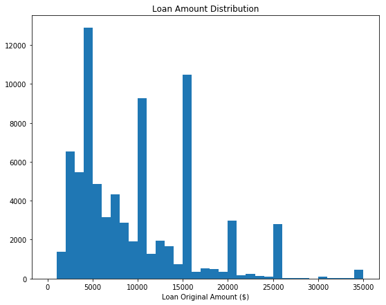

```python
binsize = 1000
bins = np.arange(0, df_loan_clean['LoanOriginalAmount'].max()+binsize, binsize)

plt.figure(figsize=[9, 7])
plt.hist(data= df_loan_clean, x= 'LoanOriginalAmount', bins=bins)
plt.xlabel("Loan Original Amount ($)")
plt.title("Loan Amount Distribution")
plt.show()
```

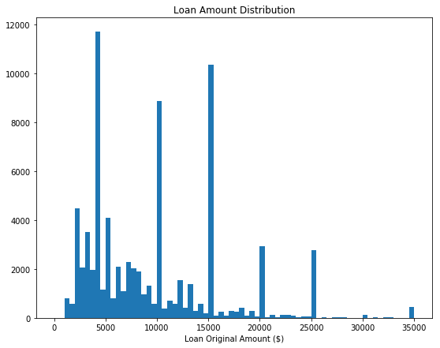

```python
# investigating further on a smaller binsize
binsize = 500
bins = np.arange(0, df_loan_clean['LoanOriginalAmount'].max()+binsize, binsize)

plt.figure(figsize=[9, 7])
plt.hist(data= df_loan_clean, x= 'LoanOriginalAmount', bins=bins)
plt.xlabel("Loan Original Amount ($)")
plt.title("Loan Amount Distribution")
plt.show()
```

### Observation

There is a spike between 3-5k, 10k, 15k, and 20k, and 25k (in $). The distribution shows that the majority of disbursed loans range at $15k and below.

## Q2 - Assessing a variable of interest, StatedMonthlyIncome.

### Visualization

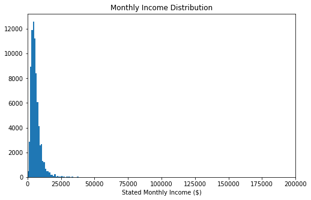

```python
# Start with a standard scaled plot
binsize = 1000
bins = np.arange(0, df_loan_clean['StatedMonthlyIncome'].max()+binsize, binsize)

plt.figure(figsize=[8, 5])
plt.hist(data= df_loan_clean, x= 'StatedMonthlyIncome', bins=bins)
plt.xlabel("Stated Monthly Income ($)")
plt.title("Monthly Income Distribution")
plt.xlim(0, 200000)
plt.show()
```

One major spike - could be due to the presence of outliers. Let's drill down further with a BoxPlot.

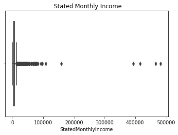

```python
sb.boxplot(data=df_loan_clean, x='StatedMonthlyIncome')
plt.title(' Stated Monthly Income');
```

These extended dots are outliers. Let's employ IQR to detect and further trim these outliers.

```python
# Using IQR method to detect outliers
Q1 = df_loan_clean['StatedMonthlyIncome'].quantile(0.25)
Q3 = df_loan_clean['StatedMonthlyIncome'].quantile(0.75)
IQR = Q3 - Q1

#Data which falls below the lower and above the upper limit is an outlier
LowerLimit = Q1 - 1.5*IQR
UpperLimit = Q3 + 1.5*IQR
print(LowerLimit, UpperLimit)
```

```
-1918.0 12618.0
```

```python
# Checking out the shape before we transform
print('Pre-transformation shape: ', df_loan_clean.shape )
```

```
Pre-transformation shape:  (77543, 20)
```

```python
# Low and high outliers
low_outliers = df_loan_clean['StatedMonthlyIncome'] < LowerLimit
print(low_outliers.sum())
```

```
0
```

```python
high_outliers = df_loan_clean['StatedMonthlyIncome'] > UpperLimit
print(high_outliers.sum())
```

```
3508
```

```python
# Outliers can be found with data above the upperlimit.
df_loan_clean = df_loan_clean[df_loan_clean['StatedMonthlyIncome'] < UpperLimit]
```

```python
# New shape
print('Post-transformation shape: ', df_loan_clean.shape)
```

```
Post-transformation shape:  (74035, 20)
```

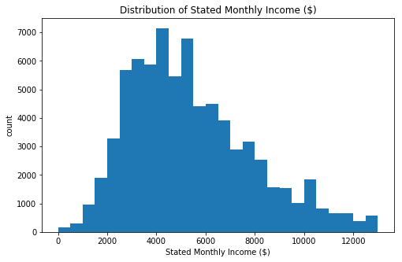

```python
# plotting with newly trimmed data

binsize = 500
bins = np.arange(0, df_loan_clean['StatedMonthlyIncome'].max()+binsize, binsize)

plt.figure(figsize=[8, 5])
plt.hist(data = df_loan_clean, x = 'StatedMonthlyIncome', bins=bins)
plt.xlabel('Stated Monthly Income ($)')
plt.ylabel('count')
plt.title('Distribution of Stated Monthly Income ($)');
plt.show()
```

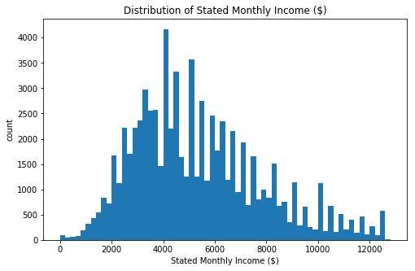

```python
# Drilling further with a smaller binsize
binsize = 200
bins = np.arange(0, df_loan_clean['StatedMonthlyIncome'].max()+binsize, binsize)

plt.figure(figsize=[8, 5])
plt.hist(data = df_loan_clean, x = 'StatedMonthlyIncome', bins=bins)
plt.xlabel('Stated Monthly Income ($)')
plt.ylabel('count')
plt.title('Distribution of Stated Monthly Income ($)');
plt.show()
```

### Observation

The initial plot for StatedMonthlyIncome showed that more low income range had more loans. Post-transformation, upon removing the outliers, it is noticed that there is a noteworthy spike at $4k.

## Q3 - Assessing a variable of interest, DebtToIncomeRatio.

#### Visualization

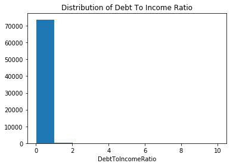

```python
# Basic histogram
plt.hist(data=df_loan_clean, x='DebtToIncomeRatio')
plt.title('Distribution of Debt To Income Ratio')
plt.xlabel('DebtToIncomeRatio');
```

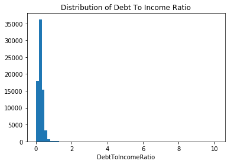

```python
# Standard plot
binsize = 0.16
bins = np.arange(0, df_loan_clean['DebtToIncomeRatio'].max()+binsize, binsize)

plt.hist(data=df_loan_clean, x='DebtToIncomeRatio', bins=bins)
plt.title('Distribution of Debt To Income Ratio')
plt.xlabel('DebtToIncomeRatio');
```

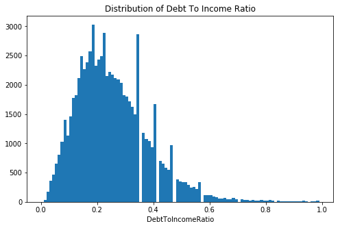

```python
# Drilling further.
bins= np.arange(0, 1, 0.01)

plt.figure(figsize=(8,5))
plt.hist(data=df_loan_clean, x='DebtToIncomeRatio', bins=bins)
plt.title('Distribution of Debt To Income Ratio')
plt.xlabel('DebtToIncomeRatio');
```

### Observation

Apparently, lenders prefer a debt-to-income ratio of about 0.35(35%) or lesser

The spikes around 0.2 and 0.36 suggests that most borrowers have debt to income ratio falling below a 0.5 threshold.

## Q4 - What Income range has the most loans?

#### Visualization

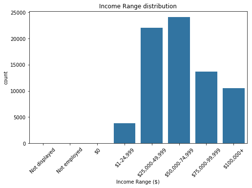

```python
plt.figure(figsize=[8, 5])
sb.countplot(x=df_loan_clean['IncomeRange'], color=base_color);
plt.title('Income Range distribution');
plt.xlabel('Income Range ($)');
plt.xticks(rotation=45);
```

### Observation

The income range of borrows hovers between $25k - $75k.

## Q5 - let's investigate the loan term

#### Visualization

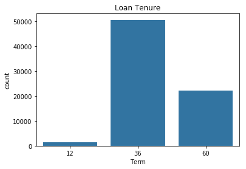

```python
sb.countplot(x=df_loan_clean['Term'], color=base_color);
plt.title('Loan Tenure');
```

### Observation

Most loans have tenure terms of 36 months (3 years) or more.

## Q6 - How does monthly repayment work?

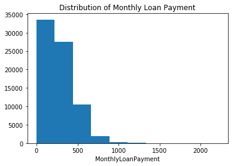

```python
# Basic histogram
plt.hist(data=df_loan_clean, x='MonthlyLoanPayment')
plt.title('Distribution of Monthly Loan Payment')
plt.xlabel('MonthlyLoanPayment');
```

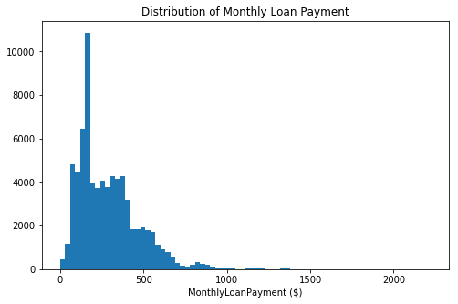

```python
# plotting on a standard scaled plot
binsize = 30
bins = np.arange(0, df_loan_clean['MonthlyLoanPayment'].max()+binsize, binsize)

plt.figure(figsize=[8, 5])
plt.hist(data = df_loan_clean, x = 'MonthlyLoanPayment', bins = bins);
plt.xlabel('MonthlyLoanPayment ($)');
plt.title('Distribution of Monthly Loan Payment');
plt.show()
```

### Observation

Majority of monthly repayments are between 0 to 500. The spike shows that a significant number of people repay around 200.

## Q7 - Guaging risk by assessing Prosper Score

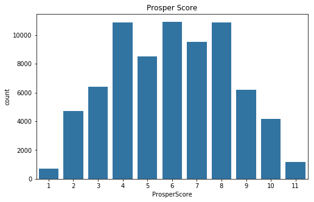

```python
plt.figure(figsize=[8, 5])
sb.countplot(x=df_loan_clean['ProsperScore'], color=base_color)
plt.title('Prosper Score');
```

The prosper score, the risk assessment criteria, appears to be trimodal with spikes at 4, 6, 8.

## Q8 - Assessing other variables in the dataset

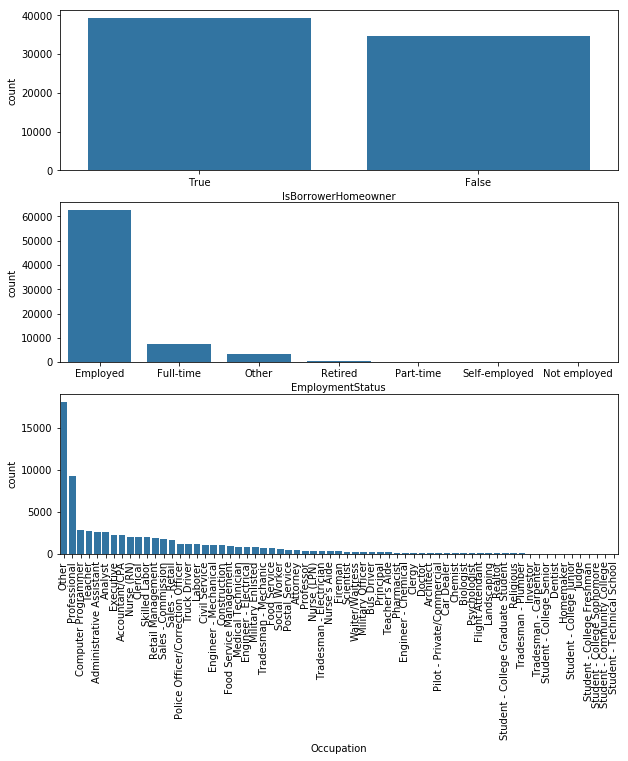

```python
fig, ax = plt.subplots(nrows=3, figsize = [10,10])

base_color = sb.color_palette()[0]
sb.countplot(data = df_loan_clean, x = 'IsBorrowerHomeowner', order = df_loan_clean['IsBorrowerHomeowner'].value_counts().index,
             color = base_color, ax = ax[0])
sb.countplot(data = df_loan_clean, x = 'EmploymentStatus', order = df_loan_clean['EmploymentStatus'].value_counts().index,
             color = base_color, ax = ax[1])
sb.countplot(data = df_loan_clean, x = 'Occupation', order = df_loan_clean['Occupation'].value_counts().index,
             color = base_color, ax = ax[2])
plt.xticks(rotation=90);

plt.show()
```

## Q9 - Assessing Ordinal Variables

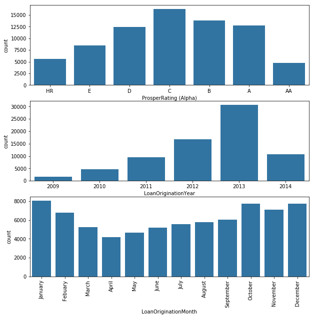

```python
fig, ax = plt.subplots(nrows=3, figsize = [10,10])

base_color = sb.color_palette()[0]
sb.countplot(data = df_loan_clean, x = 'ProsperRating (Alpha)', color = base_color, ax = ax[0])
sb.countplot(data = df_loan_clean, x = 'LoanOriginationYear', color = base_color, ax = ax[1])
sb.countplot(data = df_loan_clean, x = 'LoanOriginationMonth', color = base_color, ax = ax[2])
plt.xticks(rotation=90);

plt.show()
```

### Observation

- Prosper Rating C is the commonest, indicating that most loans have an average risk rating.
- In 2013, there was a spike in the amount of loans. I'm curious to explore the factors surrounding this trigger further.
- January, February, October, November and December were the months with the highest dibursements. This implies that there's a greater need for funds at the "beginning of the year" and at "year's end".

### Discuss the distribution(s) of your variable(s) of interest. Were there any unusual points? Did you need to perform any transformations?

> The loan origination year showed an interesting spike in distribution in year 2013.

### Of the features you investigated, were there any unusual distributions? Did you perform any operations on the data to tidy, adjust, or change the form of the data? If so, why did you do this?

> Some outliers were observed in a box plot. These outliers were dropped off for better clarity in our visualization.

> Debt-to-income ratio was skewed towards the right. To discover more insights, the data was scaled using smaller bins for further drilling.

## Bivariate Exploration

> In this section, we will investigate relationships between pairs of variables in the dataset.

## Q10 - Assessing pairwise corelations of some variables

```python
# Variable pairing (catrgorcal / numerical)
numerical_var = ['LoanOriginalAmount', 'StatedMonthlyIncome', 'DebtToIncomeRatio', 'Term', 'EmploymentStatusDuration', 'MonthlyLoanPayment']
categoric_var = ['ProsperScore', 'ProsperRating (Alpha)','EmploymentStatus', 'IsBorrowerHomeowner', 'LoanStatus']
```

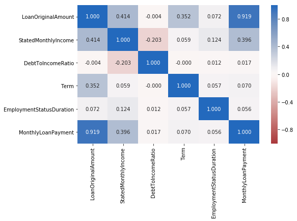

```python
# Visualizing corelation
plt.figure(figsize = [8, 5])
sb.heatmap(df_loan_clean[numerical_var].corr(), vmin = -1, vmax = 1, annot = True, fmt = '.3f',
           cmap = 'vlag_r', center = 0)
plt.show()
```

### Observation

- There is highly positive corelation between loan original amount and monthly loan payment (0.919)
- There is a weak positive corelation between stated monthly income and monthly loan payment (0.396)
- There is no corelation between Debt to income ratio and loan original amount.
- There is a weak positive corelation between term and loan original amount (0.352)

## Q11 - Assessing variable pairs

```
df_loan_clean.shape= (74035, 20)
```

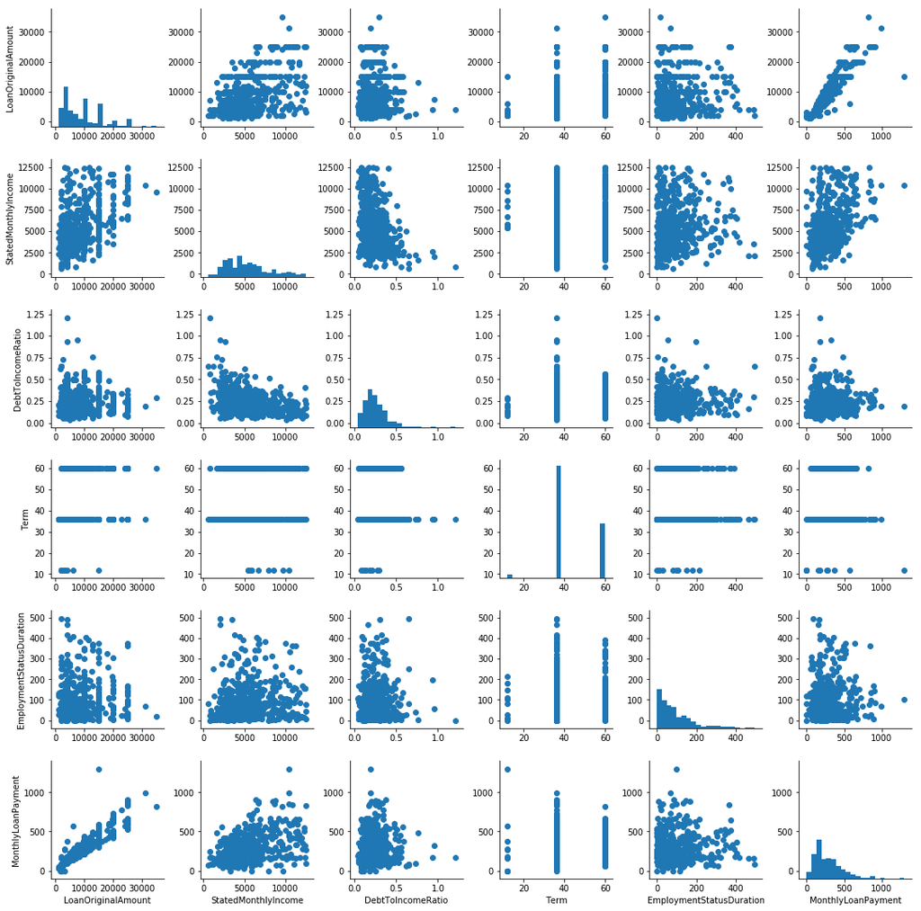

```python
# Scatter plot using random sample size
# Allows the code to run quicker.

df_loan_samp = df_loan_clean.sample(n=500, replace = False)
print("df_loan_clean.shape=",df_loan_clean.shape)

g = sb.PairGrid(data = df_loan_samp, vars = numerical_var)
g = g.map_diag(plt.hist, bins = 20);
g.map_offdiag(plt.scatter)
```

### Observation

- As expected, loan original amount and monthly loan payment have a strong positive corelation. The higher the loan amount disbursed, the greater the monthly repayment amount.
- A positive corelation also exists between stated monthly income and loan original amount. Loaning is more likely to borrowers with monthly income.

## Q12 - How does the "loan original amount" and "stated monthly income" corelate with categorical variable

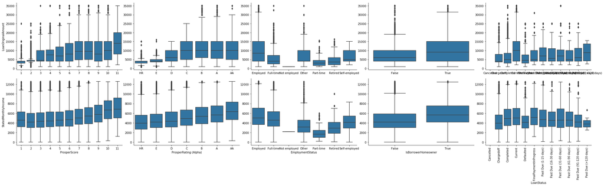

```python
# Matrix of numeric features against categorical features.

df_loan_samp = df_loan_clean.sample(n=2000, replace = False)

def boxgrid(x, y, **kwargs):
    """ Quick hack for creating box plots with seaborn's PairGrid. """
    default_color = sb.color_palette()[0]
    sb.boxplot(x=x, y=y, color = default_color)

plt.figure(figsize = [15, 15])
g = sb.PairGrid(data = df_loan_clean, y_vars = ['LoanOriginalAmount', 'StatedMonthlyIncome'], x_vars = categoric_var,
                size = 4, aspect = 1.5)
g.map(boxgrid)
plt.xticks(rotation=90)
plt.show();
```

### Observation

- An interesting corelation exists between both variables.
- Employed borrowers have more stated monthly income, and thus receive more loans. Home owners also receive more loans.
- Low risk borrowers usually have higher earnings, and tend to get more loans.

## Q13 - Taking a look at the relationship between categorical variables.

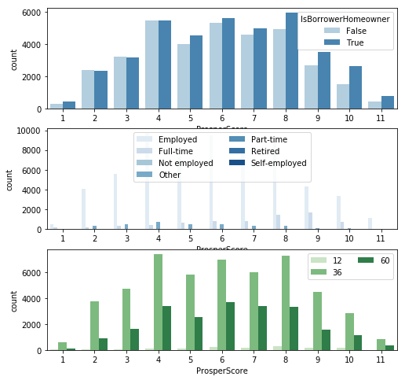

```python
# since there's only three subplots to create, using the full data should be fine.
plt.figure(figsize = [8, 8])

# subplot 1: ProsperScore vs IsBorrowerHomeowner
plt.subplot(3, 1, 1)
sb.countplot(data = df_loan_clean, x = 'ProsperScore', hue = 'IsBorrowerHomeowner', palette = 'Blues')

# subplot 2: ProsperScore vs. EmploymentStatus
ax = plt.subplot(3, 1, 2)
sb.countplot(data = df_loan_clean, x = 'ProsperScore', hue = 'EmploymentStatus', palette = 'Blues')
ax.legend(ncol = 2) # re-arrange legend to reduce overlapping

# subplot 3: ProsperScore vs. Term, use different color palette
ax = plt.subplot(3, 1, 3)
sb.countplot(data = df_loan_clean, x = 'ProsperScore', hue = 'Term', palette = 'Greens')
ax.legend(loc = 1, ncol = 2) # re-arrange legend to remove overlapping

plt.show()
```

### Observation

Several borrowers fall below the ideal ProsperScore of 10.

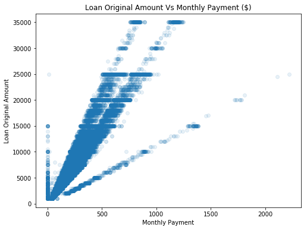

```python
# LoanOriginalAmount vs. MonthlyLoanPayment

plt.figure(figsize = [8, 6])
plt.scatter(data = df_loan_clean, x = 'MonthlyLoanPayment', y = 'LoanOriginalAmount', alpha = 1/10)
plt.xlabel('Monthly Payment')
plt.ylabel('Loan Original Amount')
plt.title('Loan Original Amount Vs Monthly Payment ($)')
plt.show()
```

### Observation

- A positive correlation exists. This is logical since the repayment amount is calculated from the Loan amount.
- Despite the corelation, the plot split in three parts, suggestive of the influence of a categorical variable.

## Q15 - Corelation between StatedMonthlyIncome and LoanOriginalAmount

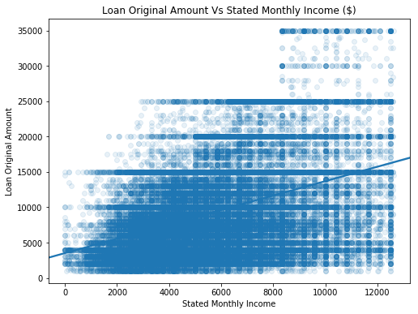

```python
plt.figure(figsize = [8, 6])
sb.regplot(data = df_loan_clean, x = 'StatedMonthlyIncome', y = 'LoanOriginalAmount',
            x_jitter=0.3, scatter_kws=({'alpha': 1/10}))
plt.xlabel('Stated Monthly Income')
plt.ylabel('Loan Original Amount')
plt.title('Loan Original Amount Vs Stated Monthly Income ($)')
plt.show()
```

### Observation

Borrowers with income greater than 8000 seem to have higher chances of getting higher loan amounts.

## Q16 - Do home-owners have access to greater loan amounts?

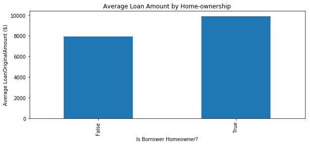

```python
plt.figure(figsize=[8,6])
df = df_loan_clean.groupby('IsBorrowerHomeowner').mean()['LoanOriginalAmount']

df_fig = df.plot(kind='bar', title="Average Loan Amount by Home-ownership",
          figsize = (10,4), color=base_color)
#Set axis labels for the df_fig plot
df_fig.set(xlabel='Is Borrower Homeowner?',
       ylabel='Average LoanOriginalAmount ($)');
```

### Observation

Homeowners do indeed seem to have access to more loans. This may be so because their properties serve as collaterals thus reducing the lending risk of default.

## Q17 - What effect does ProsperScore have on loans?

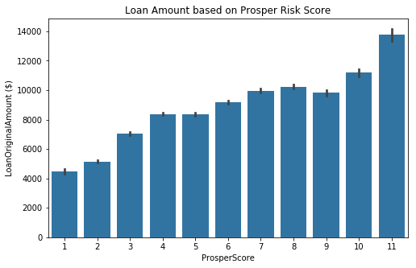

```python
plt.figure(figsize=[8,5])

sb.barplot(data=df_loan_clean, x='ProsperScore', y='LoanOriginalAmount', color=base_color)
plt.ylabel('LoanOriginalAmount ($)');
plt.title('Loan Amount based on Prosper Risk Score');
```

### Observation

The relationship between Prosper Risk Score and Loan Amount show that low-risk borrowers will generally have access to greater amounts.

## Q18 - What occupations tend to have the highest loan amounts?

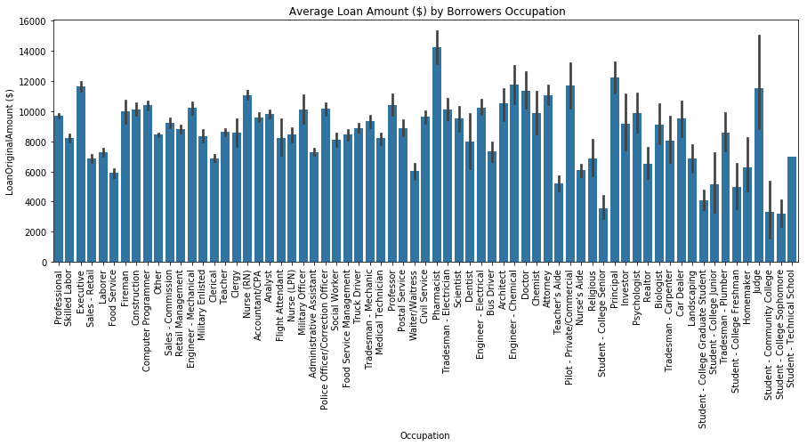

```python
plt.figure(figsize=[15,5])

sb.barplot(data=df_loan_clean, x='Occupation', y='LoanOriginalAmount', color=base_color)
plt.ylabel('LoanOriginalAmount ($)')
plt.title(' Average Loan Amount ($) by Borrowers Occupation')
plt.xticks(rotation=90);
```

### Observation

Top occupations with the highest loans inclue: Pharmacist, Judge, Principal, Engineer-Chemical. This suggests that borrowers working these jobs have higher earnings and/or good risk ratings.

### Talk about some of the relationships you observed in this part of the investigation. How did the feature(s) of interest vary with other features in the dataset?

> There is a positive corelation between Monthly Income and Loan Original amount. Borrowers with higher income are more likely to have access to higher loan amounts.

> Interestingly, the relationship between the loan amount and some of the categorical variable displayed how lenders were more likely to disburse more loans to borrowers owning homes, and those employed with low risk ratings.

> The loan original amount when plotted against the Monthly loan payment showed a positive, linear relationship.

### Did you observe any interesting relationships between the other features (not the main feature(s) of interest)?

> Upon observing the corelation between some of the categorical variables, I noticed that the all plots, when plotting some variables against the ProsperScore, were centered. This suggests that few borrowers with the perfect risk rating or loans are technically high risk.

## Multivariate Exploration

> We'd be exploring how some categorical variables relate with LoanOriginalAmount and MonthlyLoanPayment

## Q19 - Does loan term affect monthlyloanpayment and loanoriginalamount?

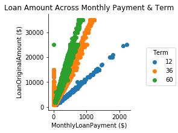

```python
g = sb.FacetGrid(data = df_loan_clean, hue = 'Term')

g.map(plt.scatter, 'MonthlyLoanPayment', 'LoanOriginalAmount');
plt.title('Loan Amount Across Monthly Payment & Term')
plt.xlabel('MonthlyLoanPayment ($)');
plt.ylabel('LoanOriginalAmount ($)')
g.add_legend();
```

### Observation

- The three lines here are being influenced by a categorical variable, as suspected. The term of the loan indeed affects the monthly loan payment and loan original amount.
- Borrowers with shorter terms (<=12 months) tend to have a higher monthly repayment rates than borrowers with longer term.

## Q20 - Does HomeOwner status and Employment staus affect Loan amount?

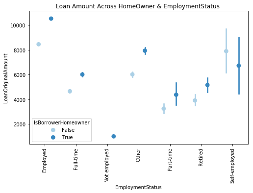

```python
fig = plt.figure(figsize = [8,5])
ax = sb.pointplot(data = df_loan_clean, x = 'EmploymentStatus', y = 'LoanOriginalAmount', hue = 'IsBorrowerHomeowner',
           palette = 'Blues', linestyles = '', dodge = 0.4)
plt.title('Loan Amount Across HomeOwner & EmploymentStatus ')
plt.ylabel('LoanOriginalAmount')
plt.xlabel('EmploymentStatus')
plt.xticks(rotation=90)
plt.show();
```

### Observation

- Lenders appear to be more willing to give loans to home-owners as previously established. This may be so because the properties are used a collateral.
- Self-employed borrowers seem to be given high amounts regardless of home-owner status. This could mean that the lender favours the likes of business men, freelancers, and other self-structured employment structures.

## Q21 - How does Term and ProsperScore affect LoanOriginalAmount?

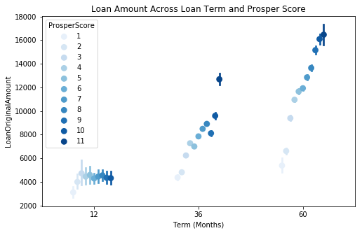

```python
fig = plt.figure(figsize = [8,5])
ax = sb.pointplot(data = df_loan_clean, x = 'Term', y = 'LoanOriginalAmount', hue = 'ProsperScore',
           palette = 'Blues', linestyles = '', dodge = 0.4)
plt.title('Loan Amount Across Loan Term and Prosper Score')
plt.ylabel('LoanOriginalAmount')
plt.xlabel('Term (Months)')
plt.show();
```

### Talk about some of the relationships you observed in this part of the investigation. Were there features that strengthened each other in terms of looking at your feature(s) of interest?

> There is a positive corelation between Monthly loan payment and Loan Original amount. The term of the loan also has an important role to play in the amount of Monthly payment. The higher the Term the lesser the Monthly Payment and vice versa. It's also interesting to note that larger Loan Amounts are issued out for longer term.

> I discovered that being a homeowner increases the chances of getting a higher loan amount and this was also influenced by the employement status of the borrower as even though a borrower has a home, being unemployed greatly reduces the chance of getting a high loan amount.

### Were there any interesting or surprising interactions between features?

> I would not say that there was something really surprising but I can say that having loan Term as a defining factor in the loan amount was not a little more than i initially thought.

## Conclusions

### Steps taken during Data Exploration

- The dataset was downloaded from the project walkthrough link and imported into my Jupyter notebook. I thereafter performed some preliminary wrangling, assessment and cleaning.
- Filteration of a subset of the data, containing only the variables I am most interested in was done.
- The first phase of the visualization was The Univariate plotting, where I explored the distribution of the main variable of interest such and Stated Monthly Income, Loan Original Amount and some other variables believed to have some influence on the main variables.
- Afterwards, Bivariate plotting, using standard heat maps to show the corelation between numerical variables, then a scatter plots using sample data size (for ease of plotting) to explore further were all employed. I also plotted a matrix grid to observe numerical variables (particularly Loan Amount) and the effects some Categorical variables had on them.
- Finally, some multivariate plotting was done where we attempted to figure if there were some other factors influencing the relationships already established in the Bivariate analyses. We discovered that Term, Employment status and Prosperscore are defining factors in Loan amount and Monthly loan payment.